# ae_waiting_time

```r
library(prob)
library(gtools)
library(e1071)
library(infer)
library(tidyverse)
library(janitor)
library(lubridate)
library(stringr)
```

```r
ae_waiting_time <- read_csv(here::here("data/ae_activity_waiting_times_apr2022-data.csv")) %>%
  clean_names()
ae_waiting_time_prior <- read_csv(here::here("data/monthly_ae_waitingtimes_A&E attendances and performance data_202201.csv")) %>%
  clean_names()
```

**Data Cleaning**

```r
ae_waiting_time_prior %>%
  left_join(ae_waiting_time_prior, location_code, by = "treatment_location", all.x = TRUE)
```

| month.x | country.x | hbt.x | treatment_location | department_type.x | number_of_attendances_aggregate.x | number_of_attendances_episode.x | number_of_attendances_episode_qf.x | number_meeting_target_aggregate.x | number_meeting_target_episode.x | number_meeting_target_episode_qf.x | discharge_destination_admission_to_same.x | discharge_destination_admission_to_same_qf.x | discharge_destination_other_specialty.x | discharge_destination_other_specialty_qf.x | discharge_destination_residence.x | discharge_destination_residence_qf.x | discharge_destination_transfer.x | discharge_destination_transfer_qf.x | discharge_destination_unknown.x | discharge_destination_unknown_qf.x | attendance_greater8hrs.x | attendance_greater8hrs_qf.x | attendance_greater12hrs.x | attendance_greater12hrs_qf.x | month.y | country.y | hbt.y | department_type.y | number_of_attendances_aggregate.y | … |
| --- | --- | --- | --- | --- | --- | --- | --- | --- | --- | --- | --- | --- | --- | --- | --- | --- | --- | --- | --- | --- | --- | --- | --- | --- | --- | --- | --- | --- | --- | --- |
| 200707 | S92000003 | S08000015 | A101H | Minor Injury Unit or Other | 252 | NA | z | 252 | NA | z | NA | z | NA | z | NA | z | NA | z | NA | z | NA | z | NA | z | 200707 | S92000003 | S08000015 | Minor Injury Unit or Other | 252 | … |
| 200707 | S92000003 | S08000015 | A101H | Minor Injury Unit or Other | 252 | NA | z | 252 | NA | z | NA | z | NA | z | NA | z | NA | z | NA | z | NA | z | NA | z | 200708 | S92000003 | S08000015 | Minor Injury Unit or Other | 265 | … |
| 200707 | S92000003 | S08000015 | A101H | Minor Injury Unit or Other | 252 | NA | z | 252 | NA | z | NA | z | NA | z | NA | z | NA | z | NA | z | NA | z | NA | z | 200709 | S92000003 | S08000015 | Minor Injury Unit or Other | 173 | … |
| 200707 | S92000003 | S08000015 | A101H | Minor Injury Unit or Other | 252 | NA | z | 252 | NA | z | NA | z | NA | z | NA | z | NA | z | NA | z | NA | z | NA | z | 200710 | S92000003 | S08000015 | Minor Injury Unit or Other | 165 | … |
| 200707 | S92000003 | S08000015 | A101H | Minor Injury Unit or Other | 252 | NA | z | 252 | NA | z | NA | z | NA | z | NA | z | NA | z | NA | z | NA | z | NA | z | 200711 | S92000003 | S08000015 | Minor Injury Unit or Other | 111 | … |
| 200707 | S92000003 | S08000015 | A101H | Minor Injury Unit or Other | 252 | NA | z | 252 | NA | z | NA | z | NA | z | NA | z | NA | z | NA | z | NA | z | NA | z | 200712 | S92000003 | S08000015 | Minor Injury Unit or Other | 140 | … |
| 200707 | S92000003 | S08000015 | A101H | Minor Injury Unit or Other | 252 | NA | z | 252 | NA | z | NA | z | NA | z | NA | z | NA | z | NA | z | NA | z | NA | z | 200801 | S92000003 | S08000015 | Minor Injury Unit or Other | 153 | … |
| 200707 | S92000003 | S08000015 | A101H | Minor Injury Unit or Other | 252 | NA | z | 252 | NA | z | NA | z | NA | z | NA | z | NA | z | NA | z | NA | z | NA | z | 200802 | S92000003 | S08000015 | Minor Injury Unit or Other | 145 | … |
| 200707 | S92000003 | S08000015 | A101H | Minor Injury Unit or Other | 252 | NA | z | 252 | NA | z | NA | z | NA | z | NA | z | NA | z | NA | z | NA | z | NA | z | 200803 | S92000003 | S08000015 | Minor Injury Unit or Other | 214 | … |
| 200707 | S92000003 | S08000015 | A101H | Minor Injury Unit or Other | 252 | NA | z | 252 | NA | z | NA | z | NA | z | NA | z | NA | z | NA | z | NA | z | NA | z | 200804 | S92000003 | S08000015 | Minor Injury Unit or Other | 210 | … |

[output cut: 990 more lines]

```r
ae_waiting_time_prior <- ae_waiting_time_prior %>%
  mutate(year = str_c(
    str_sub(month, start = 1, end = 4)), .before = 1) %>%
  mutate(month = str_c(
    str_sub(month, start = 5, end = 6)
  ))


ae_waiting_time_prior <- ae_waiting_time_prior %>%
  filter(year >= 2016)

colnames(ae_waiting_time_prior)
```

```
 [1] "year"
 [2] "month"
 [3] "country"
 [4] "hbt"
 [5] "treatment_location"
 [6] "department_type"
 [7] "number_of_attendances_aggregate"
 [8] "number_of_attendances_episode"
 [9] "number_of_attendances_episode_qf"
[10] "number_meeting_target_aggregate"
[11] "number_meeting_target_episode"
[12] "number_meeting_target_episode_qf"
[13] "discharge_destination_admission_to_same"
[14] "discharge_destination_admission_to_same_qf"
[15] "discharge_destination_other_specialty"
[16] "discharge_destination_other_specialty_qf"
[17] "discharge_destination_residence"
[18] "discharge_destination_residence_qf"
[19] "discharge_destination_transfer"
[20] "discharge_destination_transfer_qf"
[21] "discharge_destination_unknown"
[22] "discharge_destination_unknown_qf"
[23] "attendance_greater8hrs"
[24] "attendance_greater8hrs_qf"
[25] "attendance_greater12hrs"
[26] "attendance_greater12hrs_qf"
```

```r
ae_waiting_time_subset <- ae_waiting_time_prior %>%
  select("year", "month" , "treatment_location" , "department_type", "number_of_attendances_aggregate",  "number_meeting_target_aggregate","attendance_greater8hrs", "attendance_greater12hrs", "discharge_destination_admission_to_same" , "discharge_destination_other_specialty" ,"discharge_destination_residence", "discharge_destination_transfer" ,"discharge_destination_unknown")

ae_waiting_time_subset <- ae_waiting_time_subset %>%
  filter( year != "2016" | month != "01") %>%
  filter( year != "2016" | month != "02") %>%
  filter( year != "2016" | month != "03") %>%
  filter( year != "2016" | month != "04") %>%
  filter( year != "2016" | month != "05") %>%
  filter( year != "2016" | month != "06")

ae_waiting_time_subset <- ae_waiting_time_subset %>%
  mutate(year_quarter = case_when(
    str_detect(month, "01|02|03") ~ "Q1",
    str_detect(month, "04|05|06") ~ "Q2",
    str_detect(month, "07|08|09") ~ "Q3",
    str_detect(month, "10|11|12") ~ "Q4"
  ), .after = 1)

ae_waiting_time_subset <- ae_waiting_time_subset %>%
  mutate(year_quarter = str_c(year, year_quarter))

ae_waiting_time_clean <- ae_waiting_time_subset %>%
   select(c(1:9))

# filter(year != "2022") %>%
# filter(year_quarter != "2021Q4") %>%

ae_waiting_time_clean <- ae_waiting_time_clean %>%
  mutate(number_meeting_target_aggregate = coalesce(number_meeting_target_aggregate, 0)) %>%
  mutate(attendance_greater8hrs = coalesce(attendance_greater8hrs, 0)) %>%
  mutate(attendance_greater12hrs = coalesce(attendance_greater12hrs, 0))

write_csv(ae_waiting_time_subset, file = here::here("data/ae_waiting_time_subset.csv"))

write_csv(ae_waiting_time_clean, file = here::here("data/ae_waiting_time_clean.csv"))
```

```r
library(ggplot2)
```

```r
ae_waiting_time_clean <- ae_waiting_time_clean %>%
  mutate(year_quarter = as_factor(year_quarter))
```

```r
# avg_ae_waiting_time <- ae_waiting_time_clean %>%
    # group_by(year_quarter) %>%
    # summarise(mean(number_of_attendances_aggregate),
    #           mean(number_meeting_target_aggregate),
    #           mean(attendance_greater8hrs),
    #           mean(attendance_greater12hrs))
```

```r
ae_waiting_time_clean_long <- ae_waiting_time_clean %>%
  rename("hrs_waiting_4" = number_meeting_target_aggregate,
         "hrs_more_waiting_8" = attendance_greater8hrs,
         "hrs_more_waiting_12" = attendance_greater12hrs)

ae_waiting_time_clean_long_p <-ae_waiting_time_clean_long %>%
  pivot_longer(cols = c(hrs_waiting_4,hrs_more_waiting_8, hrs_more_waiting_12), names_to =  "hrs_waiting", values_to = "number_attendances") %>%
  mutate( year = as.numeric(year))

head(ae_waiting_time_clean_long_p)
```

| year | year_quarter | month | treatment_location | department_type | number_of_attendances_aggregate | hrs_waiting | number_attendances |
| --- | --- | --- | --- | --- | --- | --- | --- |
| 2016 | 2016Q3 | 07 | A101H | Minor Injury Unit or Other | 343 | hrs_waiting_4 | 340 |
| 2016 | 2016Q3 | 07 | A101H | Minor Injury Unit or Other | 343 | hrs_more_waiting_8 | 0 |
| 2016 | 2016Q3 | 07 | A101H | Minor Injury Unit or Other | 343 | hrs_more_waiting_12 | 0 |
| 2016 | 2016Q3 | 07 | A110H | Minor Injury Unit or Other | 114 | hrs_waiting_4 | 114 |
| 2016 | 2016Q3 | 07 | A110H | Minor Injury Unit or Other | 114 | hrs_more_waiting_8 | 0 |
| 2016 | 2016Q3 | 07 | A110H | Minor Injury Unit or Other | 114 | hrs_more_waiting_12 | 0 |

```r
NA
NA
NA
```

**Merge Data**

```r
location_code <- ae_waiting_time %>%
  select(3:5) %>%
  rename("treatment_location" = "treatment_location_code")
```

```r
ae_waiting_time_clean_long_p <- left_join(ae_waiting_time_clean_long_p, location_code, by = "treatment_location") %>%
  unique() %>%
  relocate(treatment_location_name, .after = 4) %>%
  relocate(hb_treatment_description, .after = 4)


ae_waiting_time_clean_long_p <- ae_waiting_time_clean_long_p %>%
  filter(department_type == "Emergency Department") %>%
  rename(region = hb_treatment_description)

write_csv(ae_waiting_time_clean_long_p, file = here::here("data/ae_waiting_time_clean_long_p.csv"))
```

**Plots** Evaluate the number of attendances for each range waiting time

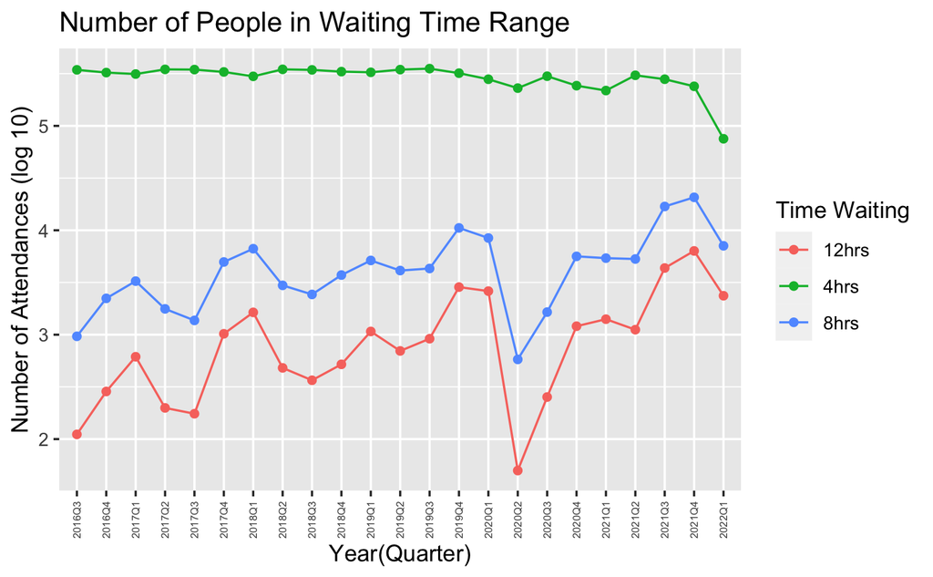

```r
#Create tibble to join as a large dataset

 plot_data_4hrs <- ae_waiting_time_clean_long_p %>%
  group_by(year_quarter) %>%
  filter(hrs_waiting == "hrs_waiting_4") %>%
  summarise(total_attendances = sum(number_attendances)) %>%
  mutate(time_waiting = "4hrs", .after = 1)

plot_data_8hrs <- ae_waiting_time_clean_long_p %>%
  group_by(year_quarter) %>%
  filter(hrs_waiting == "hrs_more_waiting_8") %>%
  summarise(total_attendances = sum(number_attendances)) %>%
  mutate(time_waiting = "8hrs", .after = 1)

plot_data_12hrs <- ae_waiting_time_clean_long_p %>%
  group_by(year_quarter) %>%
  filter(hrs_waiting == "hrs_more_waiting_12") %>%
  summarise(total_attendances = sum(number_attendances)) %>%
  mutate(time_waiting = "12hrs", .after = 1)

waiting_time_all_range <- rbind(plot_data_4hrs, plot_data_8hrs, plot_data_12hrs)

write_csv(waiting_time_all_range, file = here::here("data/waiting_time_all_range.csv"))

#Number of People in Waiting Time Range
  waiting_time_all_range %>%
  group_by(year_quarter) %>%
  ggplot()+
  aes(x = year_quarter, y = log10(total_attendances), group = time_waiting, colour = time_waiting)+
  geom_point()+
  geom_line()+
  xlab("Year(Quarter)")+ylab("Number of Attendances (log 10)")+
  theme(axis.text.x = element_text(angle = 90, size = 5, vjust = 0.5, hjust=1))+
  labs(color="Time Waiting", size = 5)+
  ggtitle("Number of People in Waiting Time Range")
```

```r
NA
NA
```

*Insights*

The total number of attendances of each quarter from 2016Q3 to 2022Q1 of different waiting time range: 4_hrs: 6837978 ppl; 8_hrs: 126149 ppl; 12_hrs: 30660 During the time, peaks existed sharply when it was Q1 and Q4. However, a massive downturn was recorded in 2020Q2, which may resulted from the measurement of lock-down.

It shows that for the 8_hrs and 12_hrs waiting time, peaks existed sharply from Q4 to Q1 before Covid(2019Q3). However, a massive downturn was recorded in 2020Q2, which may resulted from the measurement of lock-down. While after the Covid, there was another peak existed at 2021Q4.

average 297303, average 5484,average 1333

```r
waiting_time_all_range %>%
  filter(time_waiting == "8hrs") %>%
  summarise(mean(total_attendances))
```

| mean(total_attendances) |
| --- |
| 5484.739 |

```r
NA
NA
NA
```

**ready to go** The total number of attendances from 2016 to 2022

```r
#Number of A&E Attendances from 2016 to 2022
ae_waiting_time_clean_long_p %>%
  group_by(year_quarter) %>%
  summarise(total_attendances = sum(number_attendances)) %>%
  ggplot()+
  aes(x = year_quarter, y = log10(total_attendances))+
  geom_point()+
  geom_line(group = 1)+
  xlab("Year(Quarter)")+ylab("Number of Attendances(log 10)")+
  theme(axis.text.x = element_text(angle = 90, size = 5, vjust = 0.5, hjust=1))+
  labs(color="Time Waiting", size = 5)+
  ggtitle("Number of A&E Attendances from 2016 to 2022")
```

[output not shown]

**Insight**

**Statistics**

*A statistics hypothesis tested on the difference of mean between number of attendance after Covid and number of attendance before Covid. We can confirm that the mean attendances after Covid is greater than the mean attendance before Covid.

Hypothesis : two mean independent sample test with permutation.

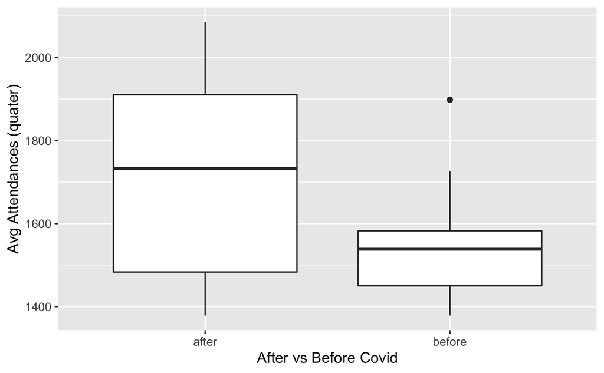

```r
#before Covid attendances mean

before_covid_attendances_avg <- ae_waiting_time_clean%>%
  group_by(year_quarter) %>%
  filter(year != "2022") %>%
  filter(year != "2021") %>%
  filter(year_quarter != "2019Q4") %>%
  summarise(avg_attendances = mean(number_of_attendances_aggregate)) %>%
  mutate(status = "before")

after_covid_attendances_avg <- ae_waiting_time_clean%>%
  group_by(year_quarter ) %>%
  filter(year != "2016") %>%
  filter(year != "2017") %>%
  filter(year != "2018") %>%
  filter(year_quarter != "2019Q1") %>%
  filter(year_quarter != "2019Q2") %>%
  filter(year_quarter != "2019Q3") %>%
  summarise(avg_attendances= mean(number_of_attendances_aggregate)) %>%
  mutate(status = "after")

waiting_time_mean <- rbind(before_covid_attendances_avg, after_covid_attendances_avg)


waiting_time_mean %>%
  ggplot(aes(x = status, y = avg_attendances))+
  geom_boxplot()+
  xlab("After vs Before Covid")+ylab("Avg Attendances (quater)")
```

```r
NA
NA
```

**Try to do some stats**

[figure not shown]

| p_value |
| --- |
| 0.013 |

The H0 is rejected. There is no evidence proof that the mean attendances after Covid is the same as the mean attendances before Covid. Since this is a right-sided test, we can confirm that the mean attendances after Covid is greater than the mean attendance before Covid.

**explore the region**

```r
region_waiting_time <- ae_waiting_time_clean_long_p %>%
  group_by(year_quarter, region) %>%
  summarise(attendances = mean(number_of_attendances_aggregate))

region_waiting_time %>%
  group_by(year_quarter) %>%
  ggplot()+
  aes(x = year_quarter, y = attendances, group = region, color = region)+
  geom_line()+
  geom_point()+
  xlab("Year(Quarter)")+ylab("Number of Attendances")+
  theme(axis.text.x = element_text(angle = 90, size = 5, vjust = 0.5, hjust=1))+
  labs(color="Time Waiting", size = 3)+
  ggtitle("Average Number of Attendances (Region)")

region_waiting_time %>%
  arrange(desc(attendances))

write_csv(region_waiting_time, file = here::here("data/region_waiting_time.csv"))
```

[output not shown]

There were 2 downturns existed in 2020Q2 and 2021Q1.

**Ethical and legal considerations including data bias**

The datasets in this report is the open data authorized by NHS Scotland and is under NHS Scotland ’s protection. We do not own the copyright of the data. The material contained in this report is distributed without profit for research and educational purposes.

The datasets recorded and collected the information of every episodes accessing the hospital services from the year of 2007 to 2022, which may not consent by patients. The data is anonymous. It contains without sensitive personal details such as address, occupancy and the reasons for accessing hospital services. However, there is a concern that the third party accessing the data for business usage.

The data may have bias since it is not standardized. Some health board are not able to provide a full record of episodes due to the limitation of resources, which may cause difference to the result.

**summary** A review on the A&E attendances During the time, peaks existed sharply when it was Q1 and Q4. However, a massive downturn was recorded in 2020Q2, which may resulted from the measurement of lock-down.

A right-sided statistics hypothesis tested on the difference of mean between number of attendance after Covid and number of attendance before Covid. The assumption of both means equal to each other is rejected (pv. 0.013). We can confirm that the mean attendances after Covid is greater than the mean attendance before Covid.